# matplotlib.pyplot.subplot_mosaic

**matplotlib.pyplot.subplot_mosaic(*mosaic*, *, *sharex=False*, *sharey=False*, *width_ratios=None*, *height_ratios=None*, *empty_sentinel='.'*, *subplot_kw=None*, *gridspec_kw=None*, *per_subplot_kw=None*, **fig_kw)[[source]](https://github.com/matplotlib/matplotlib/blob/v3.7.1/lib/matplotlib/pyplot.py#L1509-L1621)**

Build a layout of Axes based on ASCII art or nested lists.

This is a helper function to build complex GridSpec layouts visually.

See [Complex and semantic figure composition (subplot_mosaic)](https://matplotlib.org/stable/gallery/subplots_axes_and_figures/mosaic.html) for an example and full API documentation

**Parameters:**

**mosaic**list of list of {hashable or nested} or str**

A visual layout of how you want your Axes to be arranged labeled as strings. For example

```
x = [['A panel', 'A panel', 'edge'],
     ['C panel', '.',       'edge']]
```

- 'A panel' which is 1 row high and spans the first two columns
- 'edge' which is 2 rows high and is on the right edge
- 'C panel' which in 1 row and 1 column wide in the bottom left
- a blank space 1 row and 1 column wide in the bottom center

Any of the entries in the layout can be a list of lists of the same form to create nested layouts.

If input is a str, then it must be of the form

```
'''
AAE
C.E
'''
```

where each character is a column and each line is a row. This only allows only single character Axes labels and does not allow nesting but is very terse.

**sharex, sharey**bool, default: False**

If True, the x-axis (*sharex*) or y-axis (*sharey*) will be shared among all subplots. In that case, tick label visibility and axis units behave as for `subplots`. If False, each subplot's x- or y-axis will be independent.

**width_ratios**array-like of length *ncols*, optional**

Defines the relative widths of the columns. Each column gets a relative width of `width_ratios[i] / sum(width_ratios)`. If not given, all columns will have the same width. Convenience for `gridspec_kw={'width_ratios': [...]}`.

**height_ratios**array-like of length *nrows*, optional**

Defines the relative heights of the rows. Each row gets a relative height of `height_ratios[i] / sum(height_ratios)`. If not given, all rows will have the same height. Convenience for `gridspec_kw={'height_ratios': [...]}`.

**empty_sentinel**object, optional**

Entry in the layout to mean "leave this space empty". Defaults to `'.'`. Note, if *layout* is a string, it is processed via [`inspect.cleandoc`](https://docs.python.org/3/library/inspect.html#inspect.cleandoc) to remove leading white space, which may interfere with using white-space as the empty sentinel.

**subplot_kw**dict, optional**

Dictionary with keywords passed to the `Figure.add_subplot` call used to create each subplot. These values may be overridden by values in *per_subplot_kw*.

**per_subplot_kw**dict, optional**

A dictionary mapping the Axes identifiers or tuples of identifiers to a dictionary of keyword arguments to be passed to the `Figure.add_subplot` call used to create each subplot. The values in these dictionaries have precedence over the values in *subplot_kw*.

If *mosaic* is a string, and thus all keys are single characters, it is possible to use a single string instead of a tuple as keys; i.e. `"AB"` is equivalent to `("A", "B")`.

New in version 3.7.

**gridspec_kw**dict, optional**

Dictionary with keywords passed to the `GridSpec` constructor used to create the grid the subplots are placed on.

**fig_kw**

All additional keyword arguments are passed to the `pyplot.figure` call.

**Returns:**

**fig**`Figure`**

The new figure

**dict[label, Axes]**

A dictionary mapping the labels to the Axes objects. The order of the axes is left-to-right and top-to-bottom of their position in the total layout.

## Examples using `matplotlib.pyplot.subplot_mosaic`

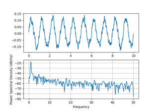

[Psd Demo](https://matplotlib.org/stable/gallery/lines_bars_and_markers/psd_demo.html#sphx-glr-gallery-lines-bars-and-markers-psd-demo-py)

Psd Demo

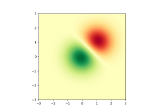

[Image demo](https://matplotlib.org/stable/gallery/images_contours_and_fields/image_demo.html#sphx-glr-gallery-images-contours-and-fields-image-demo-py)

Image demo

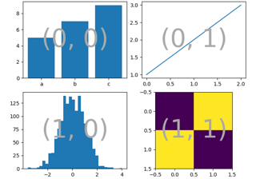

[Complex and semantic figure composition (subplot_mosaic)](https://matplotlib.org/stable/gallery/subplots_axes_and_figures/mosaic.html#sphx-glr-gallery-subplots-axes-and-figures-mosaic-py)

Complex and semantic figure composition (subplot_mosaic)

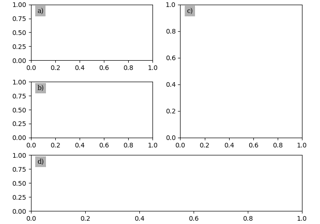

[Labelling subplots](https://matplotlib.org/stable/gallery/text_labels_and_annotations/label_subplots.html#sphx-glr-gallery-text-labels-and-annotations-label-subplots-py)

Labelling subplots

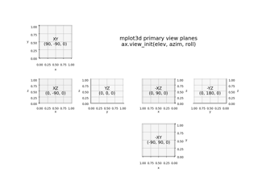

[Primary 3D view planes](https://matplotlib.org/stable/gallery/mplot3d/view_planes_3d.html#sphx-glr-gallery-mplot3d-view-planes-3d-py)

Primary 3D view planes

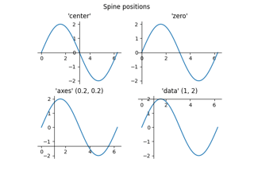

[Spine placement](https://matplotlib.org/stable/gallery/spines/spine_placement_demo.html#sphx-glr-gallery-spines-spine-placement-demo-py)

Spine placement

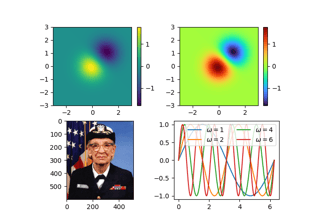

[mplcvd -- an example of figure hook](https://matplotlib.org/stable/gallery/user_interfaces/mplcvd.html#sphx-glr-gallery-user-interfaces-mplcvd-py)

mplcvd -- an example of figure hook

[Quick start guide](https://matplotlib.org/stable/tutorials/introductory/quick_start.html#sphx-glr-tutorials-introductory-quick-start-py)

Quick start guide

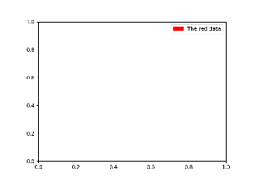

[Legend guide](https://matplotlib.org/stable/tutorials/intermediate/legend_guide.html#sphx-glr-tutorials-intermediate-legend-guide-py)

Legend guide

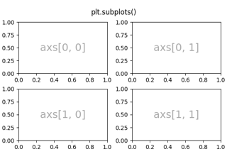

[Arranging multiple Axes in a Figure](https://matplotlib.org/stable/tutorials/intermediate/arranging_axes.html#sphx-glr-tutorials-intermediate-arranging-axes-py)

Arranging multiple Axes in a Figure